# Examples with daily climate data

Jernej Jevšenak

2025-07-18

# 1 Introduction

The dendroTools R package was developed in 2018 and is still being updated regularly and will continue to do so in the future. It provides dendroclimatological methods for analysing statistical relationships between tree rings and daily climate data. The most commonly used method is the Pearson correlation coefficient, but users can also use non-parametric correlations such as Kendall or Spearman correlations, and in the case of a multiproxy approach, linear regression can also be applied. Artificial neural networks (brnn) are also available for nonlinear analyses.

In this document I describe the basic principles behind the dendroTools R package and give some basic examples. All data included in the examples below is already included in the dendroTools R package. Please note that the examples presented here are less made computationally less intensive to accommodate the policy of CRAN. You are welcome to explore the full potential of my package by using the wide range of possible window widths.

# 2 Transformation and quick preview of daily data

One of the crucial step before using a dendroTools is to prepare climate data into a proper format. For *daily_response()* climate data must be in a format of 366 columns and n number of rows, which represent years, which are given as row names. A common format of daily data provided by many online sources is a table with two columns, where one column represents the date and the second is the value of the climate variable. To quickly transform such a format into a data frame with dimensions of 366 x n, dendroTools now offers the function *data_transform()*. The date can be in different formats, but it must be correctly speciﬁed with the argument date_format. For example, if the date is in the format “1988-01-30′′ (”year-month-day”), the argument date_format must be “ymd”.

When your data is in the proper format, the *glimpse_daily_data()* can be used for visual inspection of daily climate data. The main purpose here is to spot missing values and to evaluate the suitability of using specific daily data.

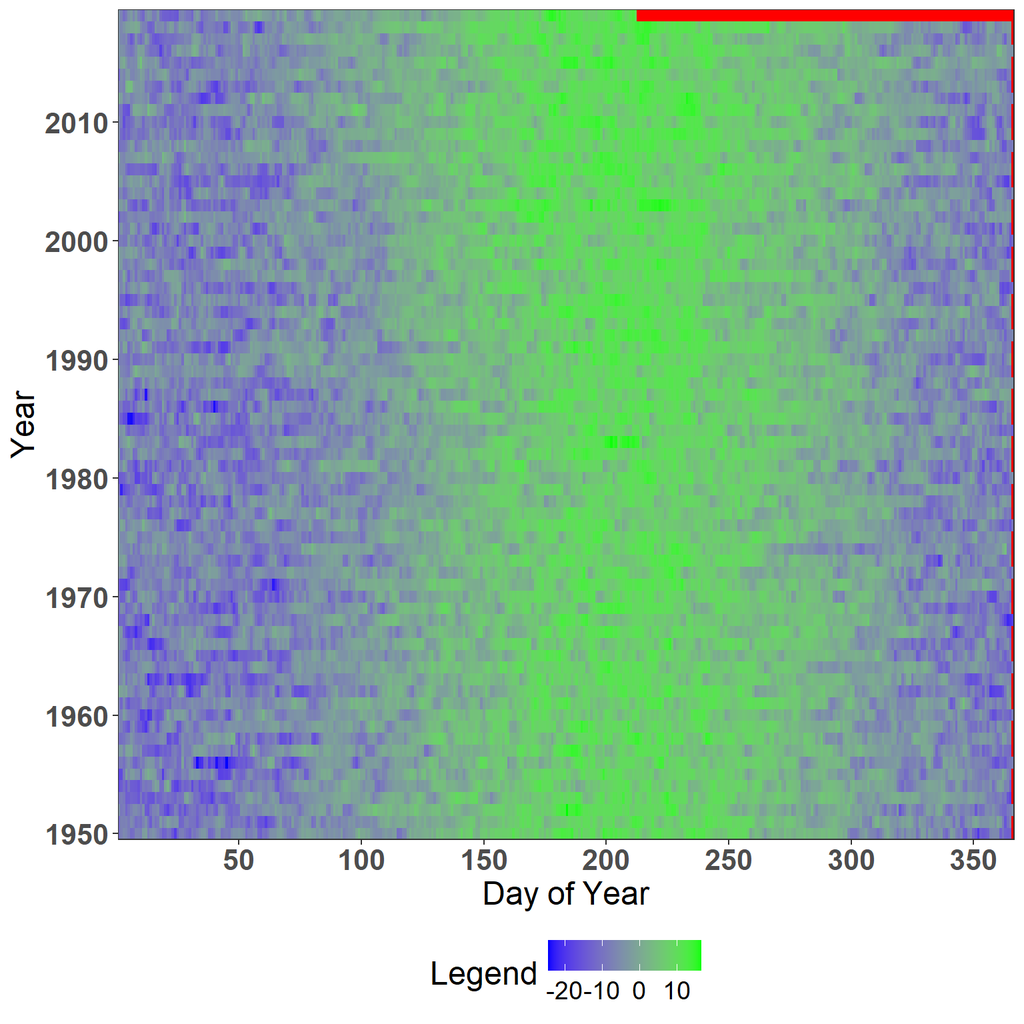

Figure 1: Glimpse of daily temperautres for swit272 site.

```r
# Load the dendroTools and ggplot2 R packages
library(dendroTools)
library(ggplot2)

# 1 Load an example data (source: E-OBS)
data("swit272_daily_temperatures")
data("swit272_daily_precipitation")

# 2 Transform data into wide format
swit272_daily_temperatures <- data_transform(swit272_daily_temperatures, format = 'daily', date_format = 'ymd')
swit272_daily_precipitation <- data_transform(swit272_daily_precipitation, format = 'daily', date_format = 'ymd')

# 3 Glimpse daily data
glimpse_daily_data(env_data = swit272_daily_temperatures, na.color = "red") +
  theme(legend.position = "bottom")
```

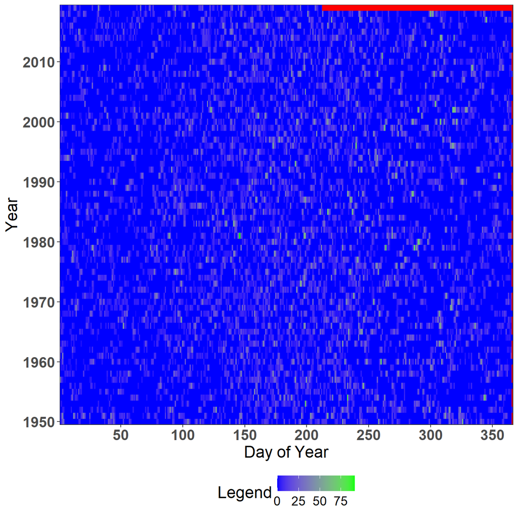

Figure 2: Glimpse of daily precipitation for swit272 site.

```r
glimpse_daily_data(env_data = swit272_daily_precipitation, na.color = "red") +
  theme(legend.position = "bottom")
```

# 3 The *daily_response()* in action

The *daily_response()* is the most commonly used function in the R package dendroTools, and works by sliding a moving window through the daily environmental (climate) data and computing statistical metrics using a tree-ring proxy. In dendroclimatology, such an analysis typically involves a site chronology that has been previously detrended, but a multiproxy approach involving multiple individual chronologies can also be used (see examples below). Possible metrics for the single-proxy approach include correlation coefficients, coefficient of determination (r-squared), and adjusted coefficient of determination (adjusted r-squared). In addition to linear regression, it is possible to use a nonlinear artificial neural network with a Bayesian regularisation training algorithm (brnn). In general, the user can use a fixed window or a progressive window to calculate the moving averages. To use a fixed window, choose its width by assigning an integer to the *fixed_width* argument. To use a so-called variable window, which includes many different windows, define the arguments *lower_limit* and *upper_limit*. In this case, all window widths between the lower and upper limits are taken into account. The window width is defined here as the number of days between the start and end days of a calculation. Thus, the window width represents a season of interest used in the calculations. All calculated statistical metrics (correlation coefficients, r-squared or adjusted r-squared) are stored in a matrix that is later used to interpret the results. Such interpretation usually involves identifying the optimal season in relation to tree-ring chronology or analysing temporal patterns of correlations between climate and growth. The so-called optimal season (also called optimal window or time window with the highest correlation value) is later extracted and used to evaluate the temporal stability correlations.

## 3.1 An example of analysing the relationship between Mean Vessel Area (MVA) tree-ring parameter and daily temperature data with fixed window approach

In this example, I analyse the relationship between the tree ring parameter Mean Early Wood Vessel Area (MVA) and daily temperature data (meteorological station Ljubljana, Slovenia) for a chosen window width of 60 days (argument *fixed_width = 60*). Note that the *fixed_width* argument overrides the *upper_limit* and *lower_limit* arguments when used.

Here I also demonstrate the usability of the *row_names_subset* argument, which I highly recommend using. In most real cases, tree-ring chronologies and climate data do not completely overlap - the chronologies are usually longer than the available climate data. So if you use the argument *row_names_subset = TRUE* , your tree ring chronology (response) and your climate data (env_data) will be automatically subdivided, keeping only the overlapping years. Therefore, it is very important that the years are correctly specified in the row names of both data inputs.

Another option I use here is to remove non-significant correlations. All non-significant correlations are removed by setting the argument *remove_insignificant = TRUE* while controlling the threshold for significance with the argument *alpha*.

The results are interpreted with generic *summary()* and visualized with the generic *plot()* functions. There are two types of plots available, 1) highlighted results for a window with the highest calculated value (type = 1), and 2) heatmap of all calculated values (type = 2).

```r
# Load the dendroTools R package
library(dendroTools)

# Load data
data(data_MVA)
data(LJ_daily_temperatures)

# Example with fixed width
example_fixed_width <- daily_response(response = data_MVA, env_data = LJ_daily_temperatures,
                                   method = "cor", fixed_width = 60,
                                   row_names_subset = TRUE, remove_insignificant = TRUE,
                                   alpha = 0.05)
```

```r
summary(example_fixed_width)
```

```
##                      Variable                                        Value
## 1                    approach                                        daily
## 2                      method            Correlation Coefficient (pearson)
## 3                      metric                                         <NA>
## 4              analysed_years                                  1940 - 2012
## 5   maximal_calculated_metric                                        0.767
## 6                    lower_ci                                         <NA>
## 7                    upper_ci                                         <NA>
## 8            reference_window Starting Day of Optimal Window Width: Day 73
## 9      analysed_previous_year                                        FALSE
## 10        optimal_time_window                              Mar 14 - May 12
## 11 optimal_time_window_length                                           60
```

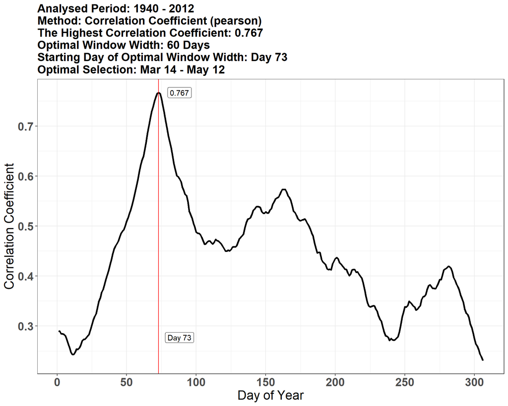

Figure 3: The MVA parameter contains the optimal temperature signal from March 14 (DOY 73) to May 12 (DOY 132).

```r
plot(example_fixed_width, type = 1)
```

## 3.2 Analysis of climate-growth correlations only for a subset of selected time interval

If users wish to restrict the time interval of interest for calculating climate-growth correlations, the *day_interval* argument can be used for daily data and *month_interval* for monthly data in *monthly_response()*. For example, if you use *daily_response()* and want to calculate correlations only from the beginning of previous October to the current end of September, use the argument *daily_interval =c(-274, 273)*. Note that a negative sign indicates previous_year doy, while a positive sign indicates the current year doy. In normal (non-leap ) years, October 1 represents doy 274, while September 30 represents doy 273. If you use *monthly_response()* and want to calculate correlations only from the beginning of the previous October to the current end of September, use the argument *monthly_interval =c(-10, 9)*. Note that a negative sign indicates the month of the previous year, while a positive sign indicates the month of the current year.

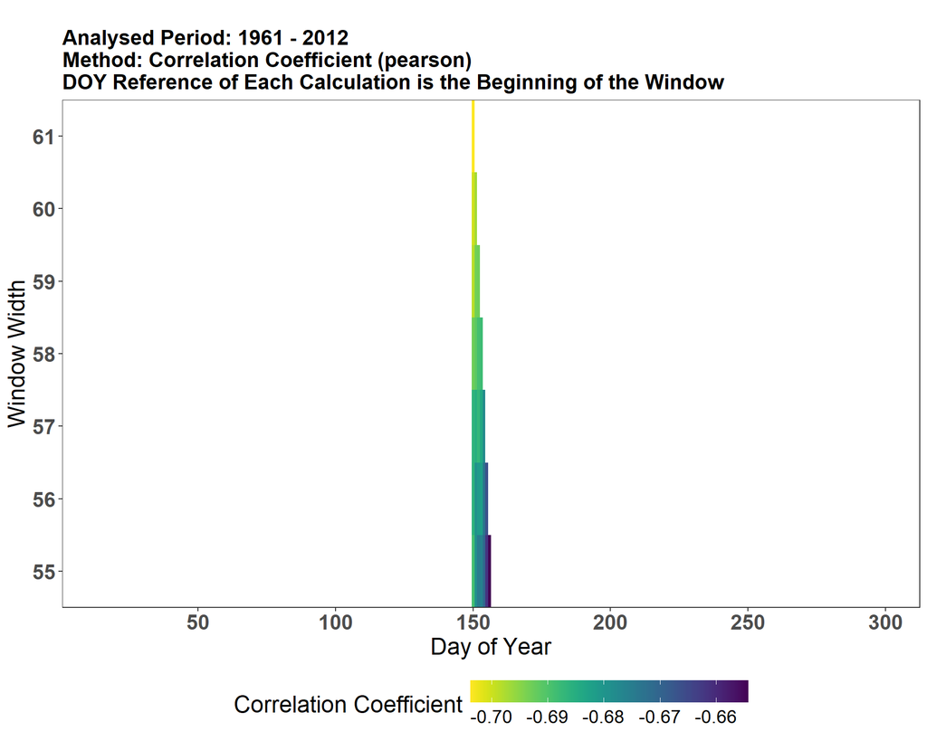

Figure 6: Climate-growth correlations calculated only for a subset of time window from DOY 150 to DOY 210

```r
# Load the dendroTools R package
library(dendroTools)

# Load data
data(data_TRW_1)
data(LJ_daily_temperatures)

# Example negative correlations
data(data_TRW_1)
example_restricted_interval <- daily_response(response = data_TRW_1, env_data = LJ_daily_temperatures,
                                   method = "cor", lower_limit = 55, upper_limit = 65,
                                   previous_year = FALSE, row_names_subset = TRUE, remove_insignificant = TRUE,
                                   alpha = 0.05, day_interval = c(150, 210))
plot(example_restricted_interval, type = 2)
```

# 4 An example with multiple tree-ring proxies

As mentioned in the introduction, *daily_response()* allows multiproxy analysis where the *response* data frame consists of more than one tree-ring proxy. In such cases, linear or non-linear (brnn) models are fitted at each step and r-squared or adjusted r-squared is computed. However, users should choose multiple proxies judiciously and with caution, as there is nothing to prevent from including colinear variables. Using multiple proxies will result in higher explained variance, but at the expense of degrees of freedom. In these cases, you should also check the stability of the relationship over time and the result of cross-validation. If the metrics on the validation data are much lower than on the calibration data, there is a problem of overfitting and you should exclude some proxies and repeat the analysis. It is highly recommended that you use the adjusted r-squared metric when using the multiproxy approach.

```r
# Load the dendroTools and brnn R package
library(dendroTools)

# Example of multiproxy analysis
data(example_proxies_1)
data(LJ_daily_temperatures)

# Summary of the example_proxies_1 data frame
summary(example_proxies_1)
```

```
##       MVA               O18                TRW
##  Min.   :0.03812   Min.   :-2.12315   Min.   :0.7851
##  1st Qu.:0.04204   1st Qu.:-0.54584   1st Qu.:0.8918
##  Median :0.04482   Median :-0.04609   Median :1.0049
##  Mean   :0.04532   Mean   : 0.04739   Mean   :1.0197
##  3rd Qu.:0.04752   3rd Qu.: 0.48215   3rd Qu.:1.1159
##  Max.   :0.05608   Max.   : 2.66724   Max.   :1.3782
```

There are three proxy variables: Tree-ring width (TRWi), stable oxygen isotopes (O18) and Mean Vessel Area (MVA).

```r
cor(example_proxies_1)
```

```
##           MVA       O18       TRW
## MVA 1.0000000 0.2114934 0.0342514
## O18 0.2114934 1.0000000 0.2702639
## TRW 0.0342514 0.2702639 1.0000000
```

The correlation matrix shows only low correlations among the three proxies.

```r
example_multiproxy <- daily_response(response = example_proxies_1,
                                     env_data = LJ_daily_temperatures,
                                     method = "lm", metric = "adj.r.squared",
                                     lower_limit = 63, upper_limit = 67,
                                     skip_window_position = 10,
                                     row_names_subset = TRUE, previous_year = FALSE,
                                     remove_insignificant = TRUE, alpha = 0.05)
```

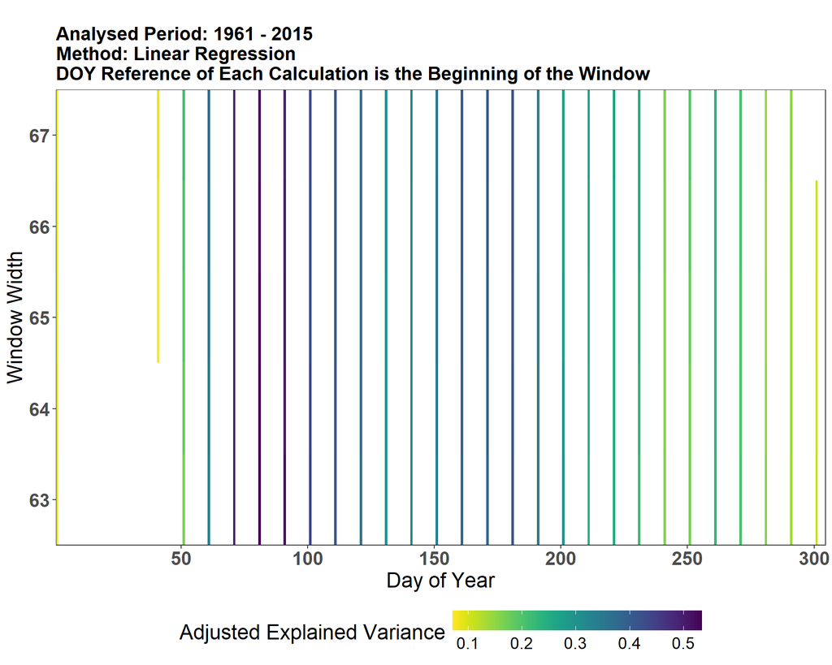

Figure 7: The temporal pattern of adjusted r-squared for the multiproxy example. The temporal pattern shows similar result than for the example with MVA only. Therefore, the highest percentage of (adjusted) explained variance is most likely related to MVA variable.

```r
plot(example_multiproxy, type = 2)
```

# 5 An example of climate reconstruction

Reconstructions of past climatic conditions include reconstructions of past temperatures, precipitation, vegetation, water flows, sea surface temperatures, and other climatic or climate-related conditions. To reconstruct climate with the dendroTools, we first use *daily_response()* to find the optimal sequence of consecutive days that yields the highest metric, e.g. correlation coefficient. In this example, we use data_TRW and the daily temperatures of Kredarica (‘KRE_daily_temperatures’). The temporal stability of the statistical relationship is afterwards analysed with the “progressive” method using 3 splits (*k = 3*). Progressive testing involves splitting the data into *k* splits, calculating the metric for the first split, and then incrementally adding 1 split at a time and calculating the selected metric. The *cross_validation_type* argument is set to “randomised” so that the years are reshuffled before the cross-validation test.

```r
# Load the dendroTools R package
library(dendroTools)

# Load data
data(data_TRW)
data(KRE_daily_temperatures)

example_reconstruction_lin <- daily_response(response = data_TRW,
                                             env_data = KRE_daily_temperatures,
                                             method = "lm", metric = "r.squared",
                                             lower_limit = 42, upper_limit = 42,
                                             row_names_subset = TRUE,
                                             temporal_stability_check = "progressive",
                                             cross_validation_type = "randomized", k = 3)
```

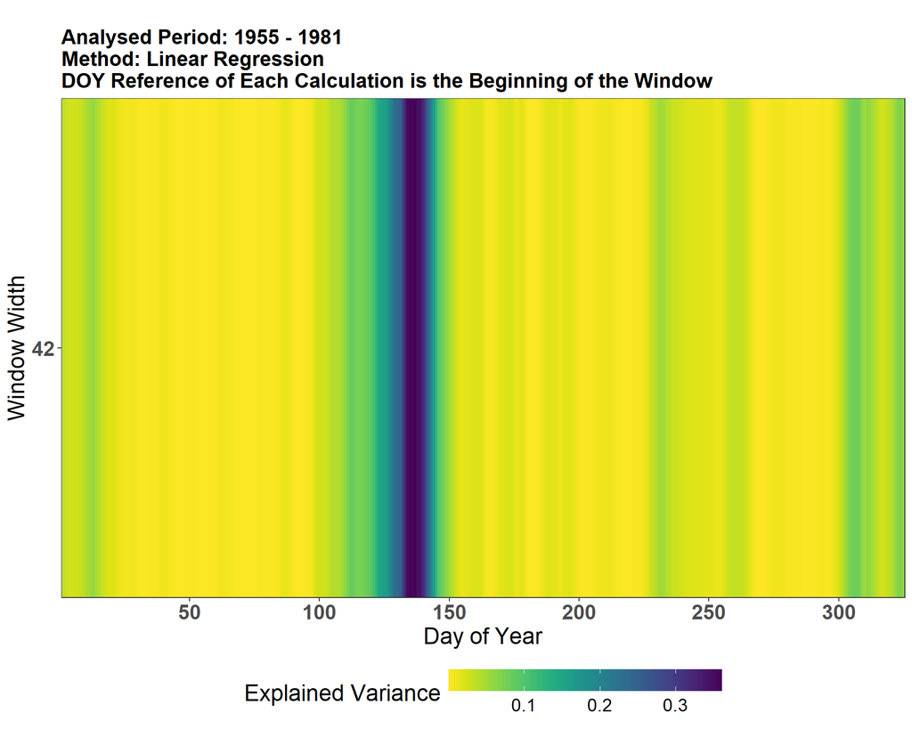

Figure 9: The highest r squared was calculated for the period from May 15 to June 27. The aggregated (averaged) daily data for this period is saved in a data frame $optimized_return.

```r
plot(example_reconstruction_lin)
```

Before reconstructing the May 15 to June 27 mean temperature, we should check temporal stability, cross validation and transfer function.

```r
example_reconstruction_lin$temporal_stability
```

```
##        Period r.squared p value
## 1 1955 - 1963     0.108      NA
## 2 1955 - 1972     0.217      NA
## 3 1955 - 1981     0.360      NA
```

```r
example_reconstruction_lin$cross_validation
```

```
##   CV      Period       cor      RMSE      RRSE         d          RE
## 1  1 Calibration 0.6619825 0.8013264 0.7495193 0.7687659          NA
## 2  1  Validation 0.4280798 0.7560160 1.0380954 0.6546000 -0.07476309
## 3  2 Calibration 0.5279018 0.8012899 0.8493054 0.6523459          NA
## 4  2  Validation 0.7389312 0.7357919 0.7241017 0.7703583  0.47912952
## 5  3 Calibration 0.6076015 0.7022152 0.7942420 0.7287717          NA
## 6  3  Validation 0.5943446 0.9070761 0.8131645 0.6406499  0.34638114
##            CE          DE
## 1          NA          NA
## 2 -0.07764197 -0.08642249
## 3          NA          NA
## 4  0.47567679  0.47331229
## 5          NA          NA
## 6  0.33876355 -0.58199369
```

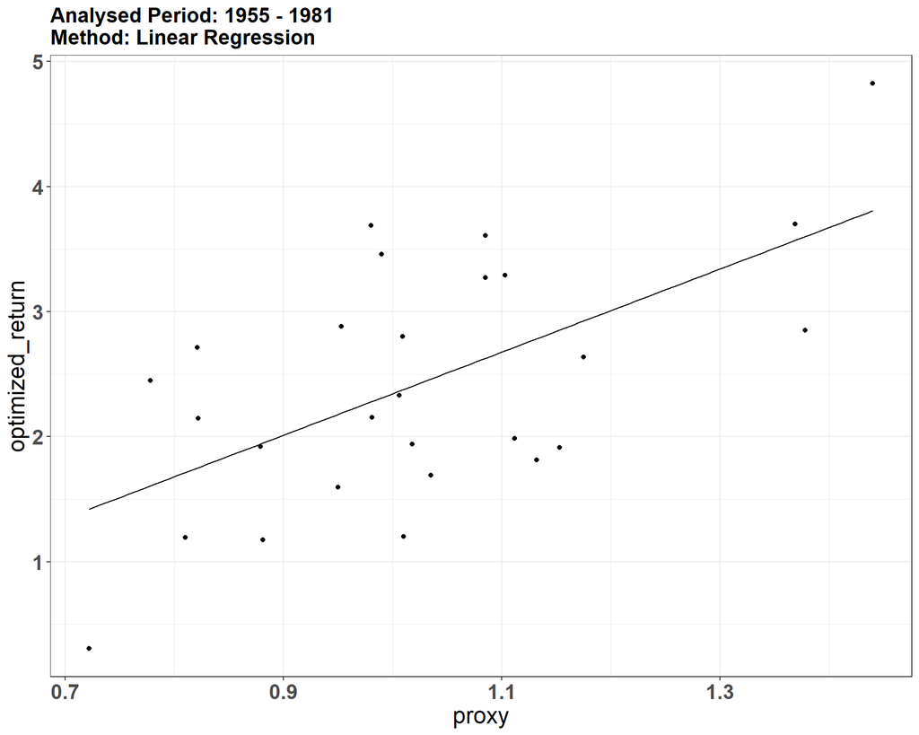

Figure 10: Linear transfer function

```r
example_reconstruction_lin$transfer_function
```

A sample code for climate reconstruction with the lm method:

```r
linear_model <- lm(Optimized_return ~ TRW, data = example_reconstruction_lin$optimized_return)
reconstruction <- data.frame(predictions = predict(linear_model, newdata = data_TRW))
```

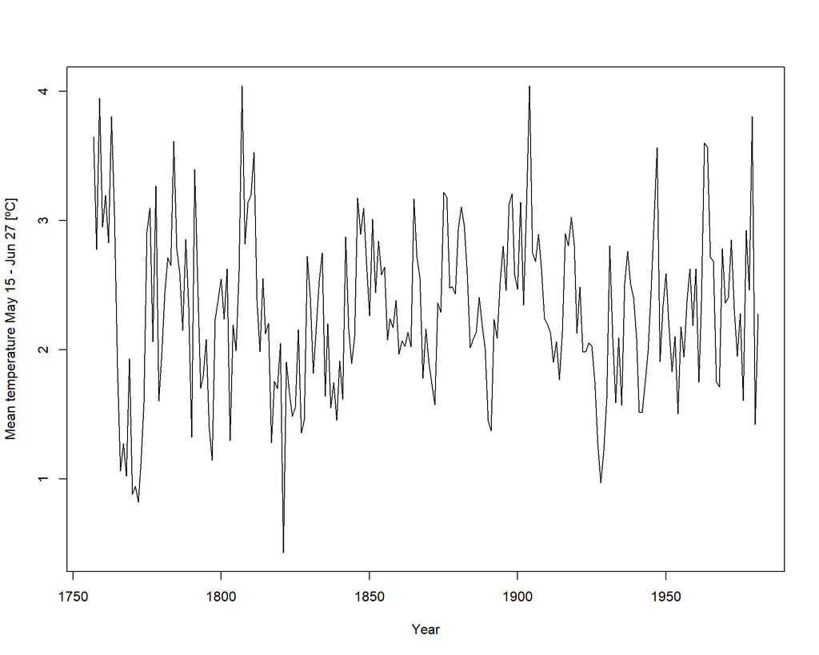

Figure 11: The reconstructed average temperature May 15 - June 27 with linear model

```r
plot(row.names(data_TRW), reconstruction$predictions, type = "l", xlab = "Year", ylab = "Mean temperature May 15 - Jun 27 [ºC]")
```

To reconstruct climate using the nonlinear brnn model, use the argument method = “brnn” (see the examples in published paper in Dendrochronologia journal).

# 6 The calculation of partial correlations with *daily_response_seascorr()*

A partial correlation coefﬁcient describes the strength of the linear relationship between two variables, holding constant a number of other variables. It is often used in dendroclimatological investigations to analyse the effect of temperature on a tree-ring parameter while at the same time controlling for the precipitation effect, or vice versa. Partial correlations in dendroTools can be calculated using *daily_response_seascorr()* and *monthly_response_seascorr()*. To analyse partial correlations, three data frames are needed: 1) a tree-ring proxy, 2) primary climate data and 3) secondary climate data for control. The tree-ring proxy must be organized as a data frame with one column representing proxy values, while years are indicated as row names. Primary climate data is assigned to the *env_data_primary* argument, while secondary climate data is assigned to *env_data_control*.

```r
# Example with precipitation and temperatures
partial_cor <- daily_response_seascorr(response = swit272,
                    env_data_primary = swit272_daily_temperatures,
                    env_data_control = swit272_daily_precipitation,
                    row_names_subset = TRUE, fixed_width = 45,
                    remove_insignificant = TRUE, alpha = 0.05,
                    aggregate_function_env_data_primary = 'mean',
                    aggregate_function_env_data_control = 'sum',
                    pcor_method = "spearman",
                    skip_window_position = 10,
                    boot = FALSE, reference_window = "end")
```

```r
summary(partial_cor)
```

```
##                      Variable                                       Value
## 1                    approach                                       daily
## 2                      method  Partial Correlation Coefficient (spearman)
## 3                      metric                                        <NA>
## 4              analysed_years                                 1950 - 2011
## 5   maximal_calculated_metric                                       0.334
## 6                    lower_ci                                        <NA>
## 7                    upper_ci                                        <NA>
## 8            reference_window Ending Day of Optimal Window Width: Day 225
## 9      analysed_previous_year                                       FALSE
## 10        optimal_time_window                             Jun 30 - Aug 13
## 11 optimal_time_window_length                                          45
```

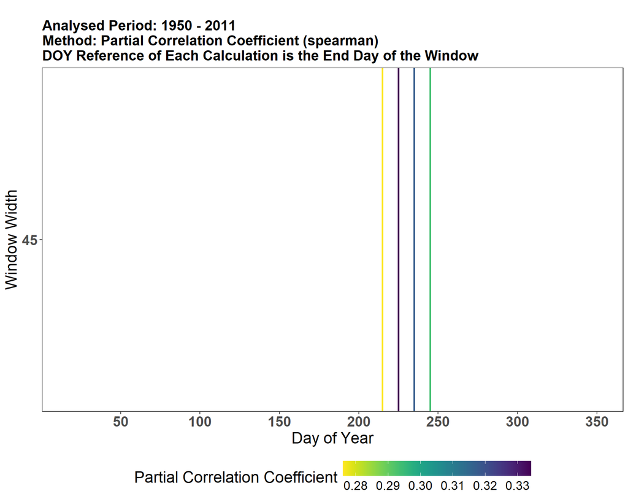

Figure 12: Temporal partern of partial climate-growth correlations calculated with daily_response_seascorr()

```r
plot(partial_cor, type = 2)
```